# 08_PracticalML_Project

Luke Richards

4/7/2021

## Introduction

The goal of this project is to demonstrate the ability to use R Machine Learning packages to analyze fitness data and identify in what manner participants did an exercise. Six participants lift barbells correctly and incorrectly in 5 different ways. We will determine which group is which from accelerometer data on the belt, forearm, arm, and dumbell.

This data was gathered from: http://groupware.les.inf.puc-rio.br/har

I assume the data is in your working directory, from the following two csv files:

https://d396qusza40orc.cloudfront.net/predmachlearn/pml-training.csv

https://d396qusza40orc.cloudfront.net/predmachlearn/pml-testing.csv

## Loading and Cleaning the Data

First we need to load our libraries and the data sets. We will name them ‘training’ and ‘testing’. We also set the seed so that our results are repeatable.

```r
library(caret)
set.seed(16903)
training <- read.csv("pml-training.csv",na.strings = c('NA','','#DIV/0!'))
testing <- read.csv("pml-testing.csv",na.strings = c('NA','','#DIV/0!'))

dim(training)
```

```
## [1] 19622   160
```

```r
dim(testing)
```

```
## [1]  20 160
```

```r
training$classe <- as.factor(training$classe)

head(training)
```

[output not shown]

[output cut: 251 more lines]

```r
zero_val <- nearZeroVar(training)
training <- training[, -zero_val]

training <- training[,colMeans(is.na(training)) < .9]
training <- training[,-c(1:7)]
```

Now, from our training data only, we we create a new training dataset and a testing dataset. The original ‘testing’ data is used for the quiz later. I use a 70/30 partition for the data, so 70% is used for training, and 30% is used for verification.

```r
in_train <- createDataPartition(training$classe, p =0.7, list=FALSE)
train1 <- training[in_train,]
test1 <- training[-in_train,]
```

## Generating training models

First we need to set up our control, I chose 3-fold cross validation per the lesson:

```r
fitControl <- trainControl(method = "cv", number = 3, verboseIter = F)
```

### Random Forests

First, we can generate a random forest training model using the below:

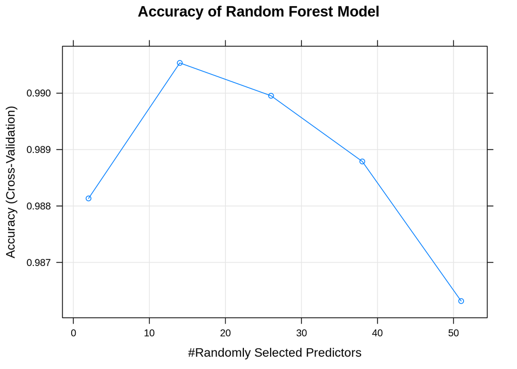

```r
mod_RF <- train(classe~., data=train1, method="rf", trControl=fitControl, tuneLength = 5)

plot(mod_RF,main = "Accuracy of Random Forest Model")
```

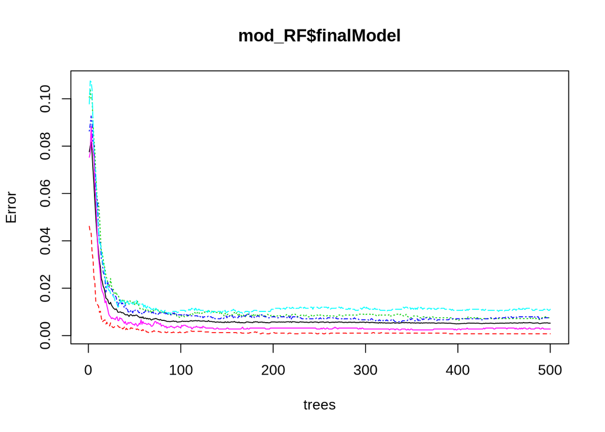

```r
plot(mod_RF$finalModel)
```

We see that generally, this is a very accurate model. Now we can try is on our test1 data.

```r
pred_train <- predict(mod_RF,newdata=test1)
rf_confmat <- confusionMatrix(test1$classe,pred_train)
rf_confmat
```

```
## Confusion Matrix and Statistics
##
##           Reference
## Prediction    A    B    C    D    E
##          A 1672    1    0    0    1
##          B    2 1136    0    0    1
##          C    0    5 1018    3    0
##          D    0    0   10  953    1
##          E    0    0    3    2 1077
##
## Overall Statistics
##
##                Accuracy : 0.9951
##                  95% CI : (0.9929, 0.9967)
##     No Information Rate : 0.2845
##     P-Value [Acc > NIR] : < 2.2e-16
##
##                   Kappa : 0.9938
##
##  Mcnemar's Test P-Value : NA
##
## Statistics by Class:
##
##                      Class: A Class: B Class: C Class: D Class: E
## Sensitivity            0.9988   0.9947   0.9874   0.9948   0.9972
## Specificity            0.9995   0.9994   0.9984   0.9978   0.9990
## Pos Pred Value         0.9988   0.9974   0.9922   0.9886   0.9954
## Neg Pred Value         0.9995   0.9987   0.9973   0.9990   0.9994
## Prevalence             0.2845   0.1941   0.1752   0.1628   0.1835
## Detection Rate         0.2841   0.1930   0.1730   0.1619   0.1830
## Detection Prevalence   0.2845   0.1935   0.1743   0.1638   0.1839
## Balanced Accuracy      0.9992   0.9971   0.9929   0.9963   0.9981
```

We see it fits very well.

### Gradient Boosting Method

Next, lets try gradient boosting with the same control.

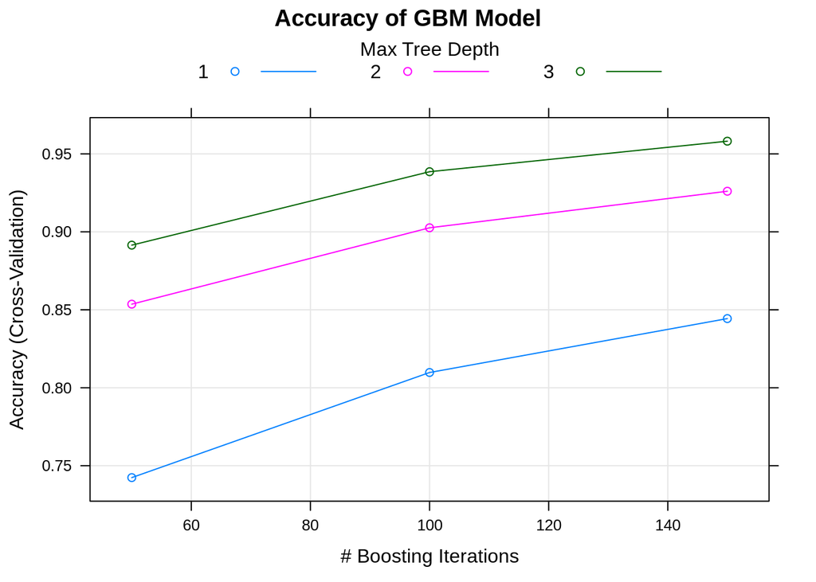

```r
mod_GBM <- train(classe~., data=train1, method = "gbm", trControl = fitControl , verbose = FALSE)

plot(mod_GBM,main = "Accuracy of GBM Model")
```

We see great accuracy, nearly as good as random forests. Nonetheless, let’s try with our test1 data.

```r
pred_train <- predict(mod_GBM,newdata=test1)
gbm_confmat <- confusionMatrix(test1$classe,pred_train)
gbm_confmat
```

```
## Confusion Matrix and Statistics
##
##           Reference
## Prediction    A    B    C    D    E
##          A 1651   15    5    3    0
##          B   35 1072   26    1    5
##          C    0   42  967   15    2
##          D    1    5   27  921   10
##          E    2    6   18    9 1047
##
## Overall Statistics
##
##                Accuracy : 0.9614
##                  95% CI : (0.9562, 0.9662)
##     No Information Rate : 0.287
##     P-Value [Acc > NIR] : < 2.2e-16
##
##                   Kappa : 0.9512
##
##  Mcnemar's Test P-Value : 2.748e-05
##
## Statistics by Class:
##
##                      Class: A Class: B Class: C Class: D Class: E
## Sensitivity            0.9775   0.9404   0.9271   0.9705   0.9840
## Specificity            0.9945   0.9859   0.9878   0.9913   0.9927
## Pos Pred Value         0.9863   0.9412   0.9425   0.9554   0.9677
## Neg Pred Value         0.9910   0.9857   0.9844   0.9943   0.9965
## Prevalence             0.2870   0.1937   0.1772   0.1613   0.1808
## Detection Rate         0.2805   0.1822   0.1643   0.1565   0.1779
## Detection Prevalence   0.2845   0.1935   0.1743   0.1638   0.1839
## Balanced Accuracy      0.9860   0.9631   0.9575   0.9809   0.9884
```

### Decision Tree

Lastly, we’ll try using decision tree per the lesson:

```r
mod_DT <- train(classe~., data=train1, method = "rpart", trControl = fitControl)

pred_train <- predict(mod_DT,newdata=test1)
dt_confmat <- confusionMatrix(test1$classe,pred_train)
dt_confmat
```

```
## Confusion Matrix and Statistics
##
##           Reference
## Prediction    A    B    C    D    E
##          A 1519   36  117    0    2
##          B  469  401  268    0    1
##          C  461   43  522    0    0
##          D  423  181  360    0    0
##          E  275  218  302    0  287
##
## Overall Statistics
##
##                Accuracy : 0.4637
##                  95% CI : (0.4509, 0.4766)
##     No Information Rate : 0.5347
##     P-Value [Acc > NIR] : 1
##
##                   Kappa : 0.2975
##
##  Mcnemar's Test P-Value : NA
##
## Statistics by Class:
##
##                      Class: A Class: B Class: C Class: D Class: E
## Sensitivity            0.4827  0.45620   0.3327       NA  0.98966
## Specificity            0.9434  0.85258   0.8832   0.8362  0.85791
## Pos Pred Value         0.9074  0.35206   0.5088       NA  0.26525
## Neg Pred Value         0.6134  0.89928   0.7845       NA  0.99938
## Prevalence             0.5347  0.14936   0.2666   0.0000  0.04928
## Detection Rate         0.2581  0.06814   0.0887   0.0000  0.04877
## Detection Prevalence   0.2845  0.19354   0.1743   0.1638  0.18386
## Balanced Accuracy      0.7130  0.65439   0.6080       NA  0.92378
```

From this we see that the decision tree method is the least accurate by far. It is not a good model for this particular test case.

## Conclusions

In summary, our three chosen methods gave us the following accuracies:

```r
rf_confmat$overall[1]
```

```
##  Accuracy
## 0.9950722
```

```r
gbm_confmat$overall[1]
```

```
##  Accuracy
## 0.9614274
```

```r
dt_confmat$overall[1]
```

```
##  Accuracy
## 0.4637213
```

I will use the random forest method to test the accuracy on our ultimate test set of data.

## Testing the model on our test data

Now we can check the results and prediction of our model on the test data provided at the start of the project.

```r
pred_data <- predict(mod_RF,newdata=testing)
pred_data
```

```
##  [1] B A B A A E D B A A B C B A E E A B B B
## Levels: A B C D E
```

These are the values used for the quiz at the end.

## Sources

Thanks to the following groups for allowing their data to be used:

Velloso, E.; Bulling, A.; Gellersen, H.; Ugulino, W.; Fuks, H. Qualitative Activity Recognition of Weight Lifting Exercises. Proceedings of 4th International Conference in Cooperation with SIGCHI (Augmented Human ’13) . Stuttgart, Germany: ACM SIGCHI, 2013.

Ugulino, W.; Cardador, D.; Vega, K.; Velloso, E.; Milidiu, R.; Fuks, H. Wearable Computing: Accelerometers’ Data Classification of Body Postures and Movements. Proceedings of 21st Brazilian Symposium on Artificial Intelligence. Advances in Artificial Intelligence - SBIA 2012. In: Lecture Notes in Computer Science. , pp. 52-61. Curitiba, PR: Springer Berlin / Heidelberg, 2012. ISBN 978-3-642-34458-9. DOI: 10.1007/978-3-642-34459-6_6.